# ISyE 6525 HW1 - Question 4

Goal: classify acoustic-emission signals as sharp (class 0) or worn (class 1).

- Part 1: cubic B-spline coefficients with 10 knots $\rightarrow$ RBF SVM.
- Part 2: FPCA scores $\rightarrow$ RBF SVM using 2, 5, 8, and 10 harmonics.
- Part 3: compare the feature representations.

```python
from pathlib import Path

import numpy as np
import pandas as pd
import matplotlib.pyplot as plt

from sklearn.decomposition import PCA
from sklearn.metrics import ConfusionMatrixDisplay, accuracy_score, confusion_matrix
from sklearn.pipeline import make_pipeline
from sklearn.preprocessing import StandardScaler
from sklearn.svm import SVC
from patsy import dmatrix

TRAIN_PATH = Path('Question4_train.csv')
TEST_PATH = Path('Question4_test.csv')
N_GRID = 128
RANDOM_STATE = 42
```

## Load and inspect the signals

The first 128 columns are signal values on an equally spaced grid $t\in[0,1]$; the last column is the class label.

```
Train: (120, 128)  Test: (60, 128)
Training class counts: [60 60]
```

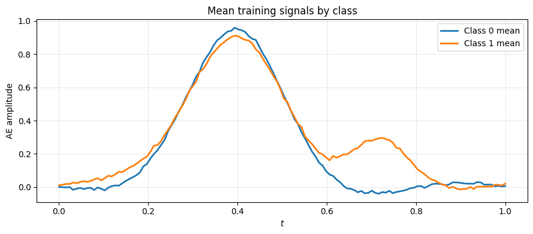

```python
for path in (TRAIN_PATH, TEST_PATH):
    if not path.exists():
        raise FileNotFoundError(f'Put {path.name} beside this notebook.')

train = pd.read_csv(TRAIN_PATH, header=None).to_numpy(dtype=float)
test = pd.read_csv(TEST_PATH, header=None).to_numpy(dtype=float)
assert train.shape == (120, 129), f'Expected train shape (120, 129), got {train.shape}'
assert test.shape == (60, 129), f'Expected test shape (60, 129), got {test.shape}'

X_train, y_train = train[:, :N_GRID], train[:, -1].astype(int)
X_test, y_test = test[:, :N_GRID], test[:, -1].astype(int)
t = np.linspace(0.0, 1.0, N_GRID)

print('Train:', X_train.shape, ' Test:', X_test.shape)
print('Training class counts:', np.bincount(y_train))

plt.figure(figsize=(9, 4))
for label, color in [(0, 'tab:blue'), (1, 'tab:orange')]:
    plt.plot(t, X_train[y_train == label].mean(axis=0), color=color,
             linewidth=2, label=f'Class {label} mean')
plt.xlabel('$t$')
plt.ylabel('AE amplitude')
plt.title('Mean training signals by class')
plt.grid(alpha=0.25)
plt.legend()
plt.tight_layout()
plt.show()
```

## Part 1: cubic B-spline coefficients + RBF SVM

Construct one common B-spline basis matrix $\Phi$ on the 128-point grid, then estimate each signal's coefficients by least squares:

$$ x_i(t)\approx\sum_j c_{ij}B_j(t). $$

```
B-spline feature shape: (120, 12)
Test accuracy: 0.833
Confusion matrix:
 [[28  2]
 [ 8 22]]
```

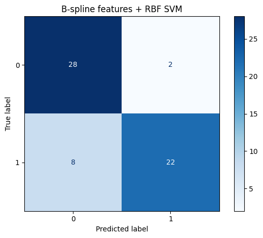

```python
N_TOTAL_KNOTS = 10
interior_knots = np.linspace(0.0, 1.0, N_TOTAL_KNOTS)[1:-1]
basis_formula = (
    f'bs(t, knots={interior_knots.tolist()}, degree=3, '
    'include_intercept=True, lower_bound=0, upper_bound=1) - 1'
)
Phi = np.asarray(dmatrix(basis_formula, {'t': t}))
# Phi shape: grid points x basis functions

def spline_coefficients(signals, basis_matrix):
    # Solve Phi @ coefficient_vector = signal for every row/signal.
    coefficients, *_ = np.linalg.lstsq(basis_matrix, signals.T, rcond=None)
    return coefficients.T

C_train = spline_coefficients(X_train, Phi)
C_test = spline_coefficients(X_test, Phi)
print('B-spline feature shape:', C_train.shape)

bspline_svm = make_pipeline(StandardScaler(), SVC(kernel='rbf'))
bspline_svm.fit(C_train, y_train)
bspline_pred = bspline_svm.predict(C_test)

bspline_accuracy = accuracy_score(y_test, bspline_pred)
bspline_cm = confusion_matrix(y_test, bspline_pred)
print(f'Test accuracy: {bspline_accuracy:.3f}')
print('Confusion matrix:\n', bspline_cm)
ConfusionMatrixDisplay(bspline_cm).plot(cmap='Blues')
plt.title('B-spline features + RBF SVM')
plt.tight_layout()
plt.show()
```

## Part 2: FPCA features

On this shared dense grid, PCA of the centered signal vectors gives the discretized FPCA solution. Fit PCA on the **training signals only**, and use the fitted transformation for the test signals.

|  | Harmonic | Fraction variance explained | Cumulative fraction |
| --- | --- | --- | --- |
| 0 | 1 | 0.637779 | 0.637779 |
| 1 | 2 | 0.227651 | 0.865430 |
| 2 | 3 | 0.097105 | 0.962535 |
| 3 | 4 | 0.021164 | 0.983699 |
| 4 | 5 | 0.000562 | 0.984261 |
| 5 | 6 | 0.000514 | 0.984774 |
| 6 | 7 | 0.000469 | 0.985243 |
| 7 | 8 | 0.000460 | 0.985703 |
| 8 | 9 | 0.000440 | 0.986143 |
| 9 | 10 | 0.000432 | 0.986575 |

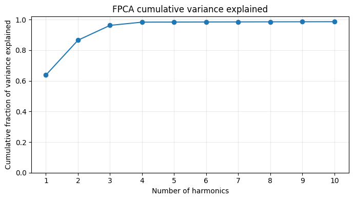

```python
fpca = PCA(n_components=10, random_state=RANDOM_STATE)
scores_train = fpca.fit_transform(X_train)
scores_test = fpca.transform(X_test)

fve = fpca.explained_variance_ratio_
cumulative_fve = np.cumsum(fve)
fve_table = pd.DataFrame({
    'Harmonic': np.arange(1, 11),
    'Fraction variance explained': fve,
    'Cumulative fraction': cumulative_fve,
})
display(fve_table)

plt.figure(figsize=(7, 4))
plt.plot(np.arange(1, 11), cumulative_fve, marker='o')
plt.xticks(np.arange(1, 11))
plt.ylim(0, 1.02)
plt.xlabel('Number of harmonics')
plt.ylabel('Cumulative fraction of variance explained')
plt.title('FPCA cumulative variance explained')
plt.grid(alpha=0.25)
plt.tight_layout()
plt.show()
```

### First four estimated eigenfunctions

The sign of an eigenfunction is arbitrary: multiplying an eigenfunction and all of its scores by $-1$ represents the same component.

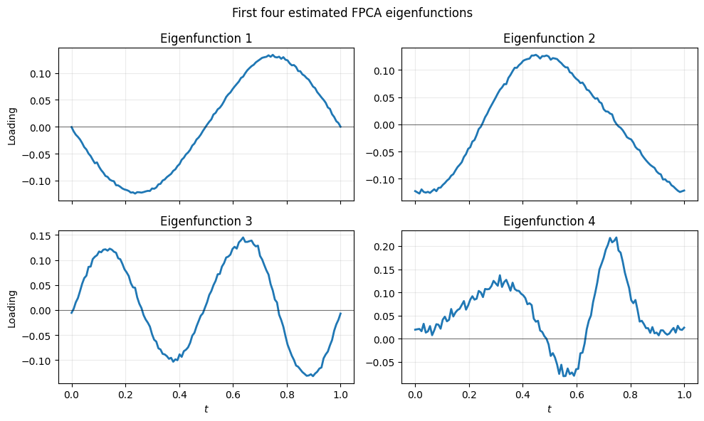

```python
fig, axes = plt.subplots(2, 2, figsize=(10, 6), sharex=True)
for k, ax in enumerate(axes.flat[:4]):
    ax.plot(t, fpca.components_[k], linewidth=2)
    ax.axhline(0, color='black', linewidth=0.8, alpha=0.5)
    ax.set_title(f'Eigenfunction {k + 1}')
    ax.grid(alpha=0.25)
for ax in axes[-1, :]:
    ax.set_xlabel('$t$')
for ax in axes[:, 0]:
    ax.set_ylabel('Loading')
fig.suptitle('First four estimated FPCA eigenfunctions')
fig.tight_layout()
plt.show()
```

### RBF SVMs using 2, 5, 8, and 10 scores

For each value of $m$, the first $m$ training scores are used to fit an RBF SVM and the corresponding test scores are used for evaluation. The output reports the test accuracy and confusion matrix for each classifier.

|  | Harmonics | Test accuracy |
| --- | --- | --- |
| 0 | 2 | 0.450000 |
| 1 | 5 | 0.900000 |
| 2 | 8 | 0.950000 |
| 3 | 10 | 0.933333 |

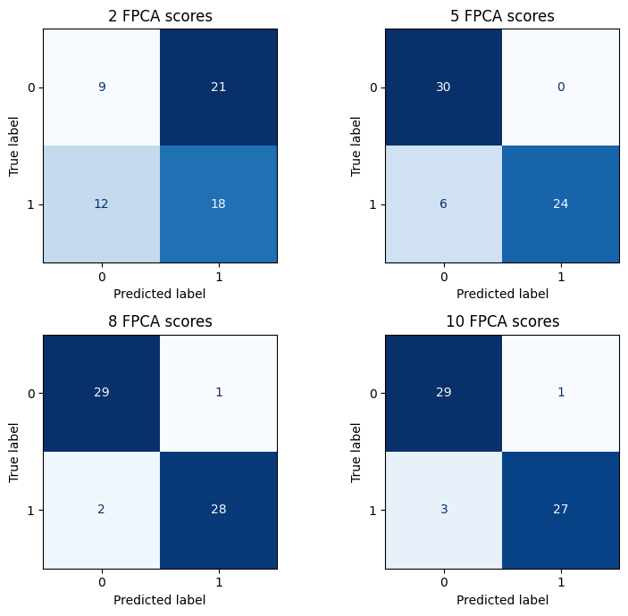

```python
n_harmonics_options = [2, 5, 8, 10]
fpca_results = []
fpca_confusion_matrices = {}

for m in n_harmonics_options:
    model = make_pipeline(StandardScaler(), SVC(kernel='rbf'))
    model.fit(scores_train[:, :m], y_train)
    pred = model.predict(scores_test[:, :m])
    acc = accuracy_score(y_test, pred)
    cm = confusion_matrix(y_test, pred)
    fpca_results.append({'Harmonics': m, 'Test accuracy': acc})
    fpca_confusion_matrices[m] = cm

display(pd.DataFrame(fpca_results))

fig, axes = plt.subplots(2, 2, figsize=(8, 7))
for m, ax in zip(n_harmonics_options, axes.flat):
    ConfusionMatrixDisplay(fpca_confusion_matrices[m]).plot(
        ax=ax, cmap='Blues', colorbar=False
    )
    ax.set_title(f'{m} FPCA scores')
fig.tight_layout()
plt.show()
```

## Part 3: comparison

The test results are summarized below. Each confusion matrix uses rows for the true class and columns for the predicted class.

| Features | Accuracy | Confusion matrix |
| --- | --- | --- |
| B-spline coefficients | 0.833 | $[[28,2],[8,22]]$ |
| 2 FPC scores | 0.450 | $[[9,21],[12,18]]$ |
| 5 FPC scores | 0.900 | $[[30,0],[6,24]]$ |
| 8 FPC scores | **0.950** | $[[29,1],[2,28]]$ |
| 10 FPC scores | 0.933 | $[[29,1],[3,27]]$ |

The B-spline coefficients gave 0.833 test accuracy, while the best FPCA model used 8 scores and achieved 0.950, so I would select the 8-score FPCA model. The first two harmonics explain 86.5% of the total variance but give only 0.450 accuracy, showing that the high-variance directions are not necessarily the directions that separate sharp and worn signals. Later harmonics can retain the smaller late-cycle wear burst, while adding too many weak components may also introduce noise, which likely explains the slight decrease from 8 to 10 scores.